# Data Mining Homework 2

Arman Zakaryan

October 12, 2017

### Problem 1

```r
load(file = 'UN_Armenia.rda')
str(armdata)
```

```
## Classes 'tbl_df', 'tbl' and 'data.frame':    380077 obs. of  15 variables:
##  $ rcid         : atomic  3664 3664 3664 3664 3664 3664 3664 3664 3664 3664 ...
##   ..- attr(*, "comment")= chr ""
##  $ country      : chr  "United States of America" "Canada" "Cuba" "Haiti" ...
##  $ country_code : chr  "US" "CA" "CU" "HT" ...
##  $ vote         : Factor w/ 3 levels "yes","abstain",..: 1 1 2 1 1 1 1 1 1 1 ...
##  $ session      : num  47 47 47 47 47 47 47 47 47 47 ...
##  $ importantvote: num  1 1 1 1 1 1 1 1 1 1 ...
##  $ date         : Date, format: "1992-10-05" "1992-10-05" ...
##  $ unres        : chr  "R/47/8" "R/47/8" "R/47/8" "R/47/8" ...
##  $ amend        : num  NA NA NA NA NA NA NA NA NA NA ...
##  $ para         : num  NA NA NA NA NA NA NA NA NA NA ...
##  $ short        : chr  "IAEA, REPORT" "IAEA, REPORT" "IAEA, REPORT" "IAEA, REPORT" ...
##  $ descr        : chr  "Report of the International Atomic Energy Agency" "Report of the International Atomic Energy Agency" "Report of the International Atomic Energy Agency" "Report of the International Atomic Energy Agency" ...
##  $ short_name   : chr  "nu" "nu" "nu" "nu" ...
##  $ issue        : chr  "Nuclear weapons and nuclear material" "Nuclear weapons and nuclear material" "Nuclear weapons and nuclear material" "Nuclear weapons and nuclear material" ...
##  $ armpres      : chr  "Ter-Petrosyan" "Ter-Petrosyan" "Ter-Petrosyan" "Ter-Petrosyan" ...
```

```r
summary(armdata)
```

```
##       rcid        country          country_code            vote
##  Min.   :3664   Length:380077      Length:380077      yes    :309747
##  1st Qu.:4201   Class :character   Class :character   abstain: 46247
##  Median :4641   Mode  :character   Mode  :character   no     : 24083
##  Mean   :4630
##  3rd Qu.:5097
##  Max.   :5465
##
##     session      importantvote         date               unres
##  Min.   :47.00   Min.   :0.0000   Min.   :1992-10-03   Length:380077
##  1st Qu.:54.00   1st Qu.:0.0000   1st Qu.:1999-12-04   Class :character
##  Median :60.00   Median :0.0000   Median :2005-12-08   Mode  :character
##  Mean   :59.55   Mean   :0.1678   Mean   :2005-06-26
##  3rd Qu.:65.00   3rd Qu.:0.0000   3rd Qu.:2010-12-21
##  Max.   :70.00   Max.   :1.0000   Max.   :2015-12-23
##
##      amend             para           short              descr
##  Min.   : NA      Min.   : NA      Length:380077      Length:380077
##  1st Qu.: NA      1st Qu.: NA      Class :character   Class :character
##  Median : NA      Median : NA      Mode  :character   Mode  :character
##  Mean   :NaN      Mean   :NaN
##  3rd Qu.: NA      3rd Qu.: NA
##  Max.   : NA      Max.   : NA
##  NA's   :380077   NA's   :380077
##   short_name           issue             armpres
##  Length:380077      Length:380077      Length:380077
##  Class :character   Class :character   Class :character
##  Mode  :character   Mode  :character   Mode  :character
##
##
##
##
```

```r
armdata$amend <- NULL
armdata$para <- NULL
```

### Problem 2

```r
class(armdata$vote)
```

```
## [1] "factor"
```

```r
levels(armdata$vote)
```

```
## [1] "yes"     "abstain" "no"
```

```r
summary(armdata$vote)
```

```
##     yes abstain      no
##  309747   46247   24083
```

As we can see, class is ‘factor’ and levels are (‘yes’, ‘no’ ‘abstain’)

### Problem 3

Common sense tells me that voting behaviour depends on the importance of the issue. As both variables are categorical, I’ll use Chi-Square test for independence. Null Hypothesis: Voting does not depend on the importance of the issue.

```r
voted <- armdata$vote!='abstain'
table(armdata$importantvote,voted)
```

```
##    voted
##      FALSE   TRUE
##   0  30911 285380
##   1  15336  48450
```

```r
chisq.test(table(armdata$importantvote,voted))
```

```
##
##  Pearson's Chi-squared test with Yates' continuity correction
##
## data:  table(armdata$importantvote, voted)
## X-squared = 10113, df = 1, p-value < 2.2e-16
```

Because of 0 $p$ value, I’ll reject the Null Hypothesis.

### Problem 4

Again, common sense tells me that each president probably had/has a different voting behaviour. Here too, I’ll use Chi-Square test to find that out. Null Hypothesis: Voting behaviour doesn’t depend on the president at the time of voting.

```r
class(armdata$armpres)
```

```
## [1] "character"
```

```r
tbl <- table(armdata$armpres, armdata$vote)
chisq.test(tbl)
```

```
##
##  Pearson's Chi-squared test
##
## data:  tbl
## X-squared = 1590.4, df = 4, p-value < 2.2e-16
```

Because of 0 $p$ value, I’ll reject the Null Hypothesis.

### Problem 5

```r
subs <- armdata[armdata$country=='Armenia',]
table(subs[,c('issue', 'vote')])
```

```
##                                       vote
## issue                                  yes abstain  no
##   Arms control and disarmament         288     144   5
##   Colonialism                          228      33   4
##   Economic development                 145      14   9
##   Human rights                         322      93  36
##   Nuclear weapons and nuclear material 175     138   3
##   Palestinian conflict                 439      55   3
```

### Problem 6

Biologically speaking, the height of a person does depend on its gender. Let’s find out if that’s true for this dataset.

Here we are dealing with one categorical and one numerical variable, so a T-test would be most appropriate. Null Hypothesis: Mean height of male children isn’t that different from the mean female children height (in other words, height does not depend on the gender of children).

```r
library(HistData)
df <- GaltonFamilies
t.test(childHeight~gender, data=df)
```

```
##
##  Welch Two Sample t-test
##
## data:  childHeight by gender
## t = -31.476, df = 929.89, p-value < 2.2e-16
## alternative hypothesis: true difference in means is not equal to 0
## 95 percent confidence interval:
##  -5.449979 -4.810266
## sample estimates:
## mean in group female   mean in group male
##             64.10397             69.23410
```

Again, because of 0 $p$ value, I’ll reject the Null Hypothesis.

### Problem 7

```r
autompg <- read.csv('auto-mpg.csv')
str(autompg)
```

```
## 'data.frame':    398 obs. of  9 variables:
##  $ mpg         : num  18 15 18 16 17 15 14 14 14 15 ...
##  $ cylinders   : int  8 8 8 8 8 8 8 8 8 8 ...
##  $ displacement: num  307 350 318 304 302 429 454 440 455 390 ...
##  $ horsepower  : Factor w/ 94 levels "?","100","102",..: 17 35 29 29 24 42 47 46 48 40 ...
##  $ weight      : int  3504 3693 3436 3433 3449 4341 4354 4312 4425 3850 ...
##  $ acceleration: num  12 11.5 11 12 10.5 10 9 8.5 10 8.5 ...
##  $ model.year  : int  70 70 70 70 70 70 70 70 70 70 ...
##  $ origin      : int  1 1 1 1 1 1 1 1 1 1 ...
##  $ car.name    : Factor w/ 305 levels "amc ambassador brougham",..: 50 37 232 15 162 142 55 224 242 2 ...
```

```r
autompg$horsepower <- as.numeric(levels(autompg$horsepower))[autompg$horsepower]
autompg$origin <- as.factor(autompg$origin)
```

### Problem 8

```r
set.seed(1)
train_ind <- sample(nrow(autompg),as.integer(0.7*nrow(autompg)))
am_train <- autompg[train_ind,]
am_test <- autompg[-train_ind,]
```

### Problem 9

```r
cor(autompg[,1:7])
```

```
##                     mpg  cylinders displacement horsepower     weight
## mpg           1.0000000 -0.7753963   -0.8042028         NA -0.8317409
## cylinders    -0.7753963  1.0000000    0.9507214         NA  0.8960168
## displacement -0.8042028  0.9507214    1.0000000         NA  0.9328241
## horsepower           NA         NA           NA          1         NA
## weight       -0.8317409  0.8960168    0.9328241         NA  1.0000000
## acceleration  0.4202889 -0.5054195   -0.5436841         NA -0.4174573
## model.year    0.5792671 -0.3487458   -0.3701642         NA -0.3065643
##              acceleration model.year
## mpg             0.4202889  0.5792671
## cylinders      -0.5054195 -0.3487458
## displacement   -0.5436841 -0.3701642
## horsepower             NA         NA
## weight         -0.4174573 -0.3065643
## acceleration    1.0000000  0.2881370
## model.year      0.2881370  1.0000000
```

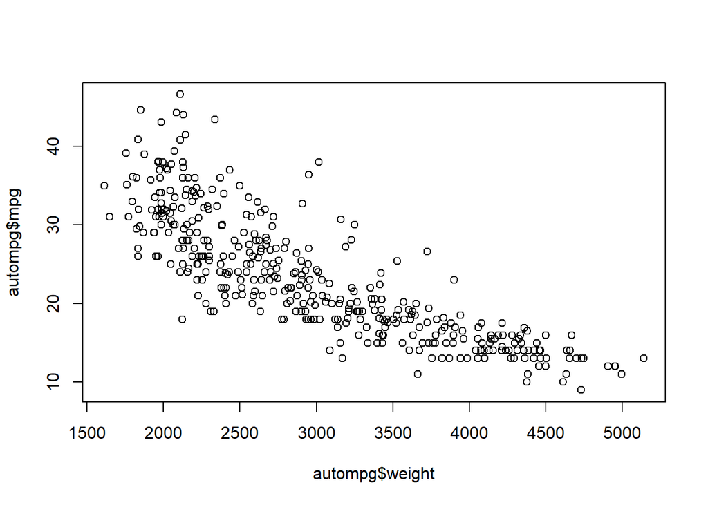

```r
plot(x=autompg$weight, y=autompg$mpg)
```

The most correlated variable is $weight$, and from the correlation coefficient and the scatterplot, its obvious that these two variables have a negative relationship.

### Problem 10

```r
max(autompg$mpg)
```

```
## [1] 46.6
```

```r
regr_data_mw <- lm(formula = mpg~weight, data=autompg)
regr_data_mw$coefficients
```

```
## (Intercept)      weight
## 46.31736442 -0.00767661
```

```r
summary(regr_data_mw)$adj.r.squared
```

```
## [1] 0.6910147
```

```r
regr_model <- lm(formula = mpg~weight, data=am_train)
am_pred <- predict(regr_model, newdata=am_test)
sqrt(mean((am_pred-am_test$mpg)^2))
```

```
## [1] 4.942095
```

RMSE is an indicator of how effective our model is. It basically shows the error that our model made compared to the ground truth. The lower its value, the better our model.

### Problem 11

Second most correlated variable is $displacement$.

```r
regr_data_md <- lm(formula = mpg~displacement, data=autompg)
regr_data_md$coefficients
```

```
##  (Intercept) displacement
##  35.17475015  -0.06028241
```

```r
summary(regr_data_md)$adj.r.squared
```

```
## [1] 0.6458501
```

```r
regr_model2 <- lm(formula = mpg~displacement, data=am_train)
am_pred2 <- predict(regr_model2, newdata=am_test)
sqrt(mean((am_pred2-am_test$mpg)^2))
```

```
## [1] 5.105605
```

### Problem 12

After observing the correlation matrix, I decided to add the variable $model.year$ to the first linear model.

```r
regr_model <- lm(formula = mpg~weight+model.year, data=am_train)
am_test_pred <- predict(regr_model, newdata=am_test)
sqrt(mean((am_test_pred-am_test$mpg)^2))
```

```
## [1] 3.926761
```

As we can see, the result has improved.

```r
am_train_pred <- predict(regr_model, newdata = am_train)
sqrt(mean((am_train_pred-am_train$mpg)^2))
```

```
## [1] 3.219411
```

RMSE’s are pretty close to each other, so most probably no underfitting or overfitting took place.